# De Elan à Universal Dependencies

# From Elan to Universal Dependecies

#### 10/12/2020

### Alexey Koshevoy

Département d'études cognitives, ENS Paris

Code: https://tinyurl.com/yxfgf73x

## Structure of the tutorial

- Introduction
  - Required packages, required repositories
- From .eaf to ConLL-U format
- Adding morphological annotation

## Introduction

Requirements

- Python 3
- pip
- git
- pympi-ling and jupyter

```python
!pip3 install -r requirements.txt
```

F. Tyers ud-scripts: we will only use the conllu-feats.py file:

```python
!git clone https://github.com/ftyers/ud-scripts
```

```
fatal: целевой путь «ud-scripts» уже существует и не является пустым каталогом.
```

Then copy-paste the conllu-feats.py to the root of this directory

## From .eaf to .conll

- How does the inital data look?

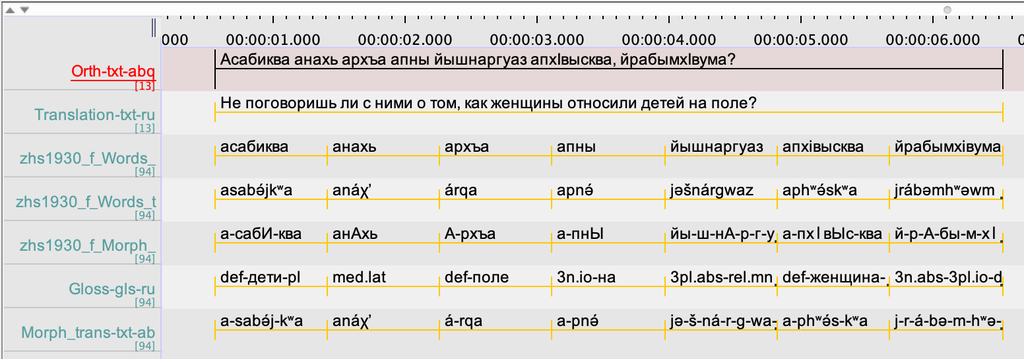

```python
Image(filename='pics/eaf_looks.png')
```

Required tiers:

- Orthography tier (if there is some written tradition, it's better to use it instead of IPA)
- Word-by-word segmentation level
- Glosses for each word
- NB: the tiers should have identical names across all .eaf files

Directory structure:

```
├── ELAN
│   ├── file1.eaf
│   ├── file2.eaf
|   ├── file2.eaf
|   ├── ...
├── EafToUD.py
```

Import the EafToUd class

```python
from EafToUD import EafToUD
```

Indicate the directory name, the name of the tier with complete sentences, and glosses

```python
eaf_transformer = EafToUD(directory='ELAN',
                          sent_tier='Orth-txt-abq',
                          morph_tier='Gloss-gls-ru')
```

```
ELAN/Repka_AjsanovaFB_11072017.eaf
Parsing unknown version of ELAN spec... This could result in errors...
ELAN/Deti_v_pole_SanashokovaCKh_13072017.eaf
Parsing unknown version of ELAN spec... This could result in errors...
```

Call the **make_conll_file** method with the name of the output file as argument

```python
eaf_transformer.make_conll_file('trial.conll')
```

What does EafToUd do?

- Extracts the needed tiers
- Transforms the glosses into the machine-readable format
- Fits the data into the .conll template

How does the result look?

```
# sent_id = 8
# text_name = Repka_AjsanovaFB_11072017.eaf
# text = ахыгIвгьи ацахъын йахътI йахъын йгьрызгIалымхтI
# text_init = АхыгIвгьи ацАхъын йАхътI йАхъын йгьрызгIалЫмхтI
1   ахыгiвгьи   _   _   _   def|add _   _   _   Gloss=def-трое-add
2   ацахъын _   _   _   rec.io|com|3n.io|pst    _   _   _   Gloss=rec.io-com-3n.io-тянуть-pst
3   йахътi  _   _   _   3h.abs|3n.io|dcl    _   _   _   Gloss=3h.abs-3n.io-тянуть-dcl
4   йахъын  _   _   _   3h.abs|3n.io|pst    _   _   _   Gloss=3h.abs-3n.io-тянуть-pst
5   йгьрызгiалымхтi _   _   _   3n.abs|neg.emp|3pl.io|pot|csl|loc|neg|dcl   _   _   _   Gloss=3n.abs-neg.emp-3pl.io-pot-csl-loc-neg-копать-dcl
```

- NB: no punctuation
- No morphological tags in the required format

## Adding morphological annotation

- From def|pl to Definite=Def|Number=Plur
- POS-tags where possible
- Map all interlinear glossed presented in your dataset to XPOS features
- Create a XPOS.udx file

```
_   _   def _   _   NOUN    Definite=Def    _
_   _   indef   _   _   NOUN    Definite=Ind    _
_   _   indf    _   _   NOUN    Definite=Ind    _
_   _   ins _   _   _   Case=Ins    _
_   _   dat _   _   _   Case=Dat    _
_   _   neg _   _   _   Polarity=Neg    _
```

For easier annotation, you can use **EaftoUD**:

```python
eaf_transformer.make_gloss_file('testXPOS.udx')
```

- Now you can annotate it

```
_   _   3m.abs  _   _   POS XPOS    _
_   _   prox    _   _   _   _   _
_   _   ben _   _   _   _   _
_   _   3pl.io  _   _   _   _   _
_   _   .pl _   _   _   _   _
```

- Automatically annotate .conll file

```python
!cat trial.conll | python3 conllu-feats.py abazaXPOS.udx > trial-XPOS.conllu
```

[output not shown]

[output cut: 420 more lines]

[output not shown]

- This code concatenates our ConLL-U file with the given annotations based on glosses
- How does the result look?

```
# sent_id = 8
# text_name = Repka_AjsanovaFB_11072017.eaf
# text = ахыгIвгьи ацахъын йахътI йахъын йгьрызгIалымхтI
# text_init = АхыгIвгьи ацАхъын йАхътI йАхъын йгьрызгIалЫмхтI
1   ахыгiвгьи   _   NOUN    _   Definite=Def    _   _   _   Gloss=def-трое-add|_|_|def|add
2   ацахъын _   VERB    _   Case=Com|Gender[dat]=Neut|Number[dat]=Sing|Person[dat]=3|Tense=Pst  _   _   _   Gloss=rec.io-com-3n.io-тянуть-pst|_|_|rec.io|com|3n.io|pst
3   йахътi  _   _   _   Gender[abs]=Com|Gender[dat]=Neut|Number[abs]=Sing|Number[dat]=Sing|Person[abs]=3|Person[dat]=3  _   _   _   Gloss=3h.abs-3n.io-тянуть-dcl|_|_|3h.abs|3n.io|dcl
4   йахъын  _   VERB    _   Gender[abs]=Com|Gender[dat]=Neut|Number[abs]=Sing|Number[dat]=Sing|Person[abs]=3|Person[dat]=3|Tense=Pst    _   _   _   Gloss=3h.abs-3n.io-тянуть-pst|_|_|3h.abs|3n.io|pst
5   йгьрызгiалымхтi _   VERB    _   Gender[abs]=Neut|Mood=Pot|Number[abs]=Sing|Number[dat]=Plur|Person[abs]=3|Person[dat]=3|Polarity=Neg    _   _   _   Gloss=3n.abs-neg.emp-3pl.io-pot-csl-loc-neg-копать-dcl|_|_|3n.abs|neg.emp|3pl.io|pot|csl|loc|neg|dcl
```

## Conclusions

- From .eaf to .conll in a few relatively simple steps
- Annotated spoken corpora could be used as UD-Treebanks
- Better version of EafToUd in future, maybe as a package

## Thank you!

##### alexeykochevoy@gmail.com

##### or alexey.koshevoy@ens.fr